# Practical 4: Answers

Vahe Avagyan  
Mathematical & Statistical Methods group – Biometris  
Wageningen University & Research  
**Linear and Generalized Linear Models**

vahe.avagyan@wur.nl

### Packages

First, you need install and load the required R packages.

```r
## Set working directory to convenience
setwd(" ")

## Packages (install and invoke)
pkgs <- rownames(installed.packages())
if(!"faraway" %in% pkgs) install.packages("faraway")
if(!"car" %in% pkgs) install.packages("car")
```

The code recognizes if certain packages are missing from your package library and, if so, will install them automatically.

Now, we need to load the packages:

```r
library(faraway)
library(MASS)
library(car)
```

## Exercise 1.

Verify that in the sum-of-squares function, the following two expressions are the same

$S(\textbf{b}) = \textbf{y}'\textbf{y} - \textbf{y}'\textbf{X}\textbf{b} - \textbf{b}'\textbf{X}'\textbf{y} + \textbf{b}'\textbf{X}'\textbf{X}\textbf{b}$.

$S(\textbf{b}) = \textbf{y}'\textbf{y} - 2\textbf{y}'\textbf{X}\textbf{b} + \textbf{b}'\textbf{X}'\textbf{X}\textbf{b}$.

See slide 32

**Answer**

We simply need to show that $- \textbf{y}'\textbf{X}\textbf{b} - \textbf{b}'\textbf{X}'\textbf{y}$ and $- 2\textbf{y}'\textbf{X}\textbf{b}$ are identical.

First, we can see that $\textbf{b}'\textbf{X}'\textbf{y} = (\textbf{y}'\textbf{X}\textbf{b})'$. On the other hand, it is easy to check that both terms are scalars. Transposing a scalar doesn’t change the scalar. The dimensions in the product are $(1\times n) \times (n \times (k+1)) \times ((k+1) \times 1)$.

## Exercise 2.

1. Show that the variance-covariance matrix of the LS coefficients is $V(\textbf{b}) = \sigma^2 (\textbf{X}'\textbf{X})^{-1}$.
2. $\textbf{(Optional, try after exercise 6)}$ Suppose $A=b_0$ is the intercept and $B=b_1$ is the slope of simple linear regression. Show the sampling variance of A and B are:

$V(A) = \sigma^2 \sum X_i^2 / (n\sum (X_i - \bar{X})^2)$

$V(B) = \sigma^2 / \sum (X_i - \bar{X})^2$

Hint: for inverting a $2\times 2$ matrix, use the formula

$\begin{bmatrix}a & b \\ c & d\end{bmatrix}^{-1} =\begin{bmatrix}d & -b \\ -c & d\end{bmatrix} \times 1/(ad-bc)$

**Answer**

1. We have $\textbf{b} = M\textbf{y}$, for some $M$. Thus,

$V(\textbf{b}) =V(M\textbf{y}) = M V(\textbf{y})M' =(\textbf{X}'\textbf{X})^{-1}\textbf{X}' \sigma^2 I_n ((\textbf{X}'\textbf{X})^{-1}\textbf{X}')' = \sigma^2 (\textbf{X}'\textbf{X})^{-1}(\textbf{X}'\textbf{X}) (\textbf{X}'\textbf{X})^{-1} = \sigma^2 (\textbf{X}'\textbf{X})^{-1}$.

b)For the simple linear regression, we have the design matrix $X$ has dimension $n \times 2$ (the column of ones and the predictor). Therefore,

$$X'X = \begin{bmatrix}n & \sum X_i \\ \sum X_i & \sum X_i^2\end{bmatrix}$$

Using the general formula for the inverse of $2 \times 2$ matrix, we get

$$(X'X)^{-1} = 1 / \left(n \sum X_i^2 - (\sum X_i)^2\right)\begin{bmatrix}\sum X_i^2 & -\sum X_i \\ -\sum X_i & n\end{bmatrix}$$

Now, $V(A)$ is the first entry of the diagonal element of $\sigma^2 (\textbf{X}'\textbf{X})^{-1}$, and $V(B)$ is its second entry.

Let’s start with the variance of the slope:

$V(B) = \sigma^2 n / \left(n \sum X_i^2 - (\sum X_i)^2\right) = \sigma^2 / \left( \sum X_i^2 - (\sum X_i)^2/n\right) = \\$ $= \sigma^2 / \left( \sum X_i^2 - 2(\sum X_i)^2/n + (\sum X_i)^2/n\right) \\$ $=\sigma^2 / \left( \sum X_i^2 - 2\sum X_i \times \sum X_i/n + n\sum X_i \times \sum X_i /n^2\right)=\\$ $=\sigma^2 / \left(\sum X_i^2 - 2\sum X_i \times \bar{X} + n(\bar{X})^2\right)=\\$ $=\sigma^2 / \left(\sum X_i^2 -\bar{X} \right)^2$

Take similar steps for variance of intercept:

$V(A) = \sigma^2 \sum X_i^2 / (n\sum (X_i^2 - \bar{X})^2)$

## Exercise 3.

Using R, obtain the LS estimated coefficient for the regression that you have seen during the lecture (regress prestige against income and education).

1. Perform matrix computations and compute the LS coefficients $b=(X'X)^{-1}X'y$.

```r
y <- Duncan$prestige
(X <- cbind(1,Duncan$income,Duncan$education))
```

```
##       [,1] [,2] [,3]
##  [1,]    1   62   86
##  [2,]    1   72   76
##  [3,]    1   75   92
##  [4,]    1   55   90
##  [5,]    1   64   86
##  [6,]    1   21   84
##  [7,]    1   64   93
##  [8,]    1   80  100
##  [9,]    1   67   87
## [10,]    1   72   86
## [11,]    1   42   74
## [12,]    1   76   98
## [13,]    1   76   97
## [14,]    1   41   84
```

[output cut: 31 more lines]

```r
#Least squares coefficients:
(Xinv=solve(t(X)%*%X))
```

```
##               [,1]          [,2]          [,3]
## [1,]  0.1021058996 -8.495732e-04 -8.432006e-04
## [2,] -0.0008495732  8.012198e-05 -4.766131e-05
## [3,] -0.0008432006 -4.766131e-05  5.401182e-05
```

```r
(b <- Xinv %*% t(X) %*% y)
```

```
##            [,1]
## [1,] -6.0646629
## [2,]  0.5987328
## [3,]  0.5458339
```

2. Use the `lm()` command to obtain the same coefficients and ask for the `summary()`.

```r
#Least squares estimates using lm:
lse <- lm(prestige ~ income + education, data=Duncan)
summary(lse)
```

```
##
## Call:
## lm(formula = prestige ~ income + education, data = Duncan)
##
## Residuals:
##     Min      1Q  Median      3Q     Max
## -29.538  -6.417   0.655   6.605  34.641
##
## Coefficients:
##             Estimate Std. Error t value Pr(>|t|)
## (Intercept) -6.06466    4.27194  -1.420    0.163
## income       0.59873    0.11967   5.003 1.05e-05 ***
## education    0.54583    0.09825   5.555 1.73e-06 ***
## ---
## Signif. codes:  0 '***' 0.001 '**' 0.01 '*' 0.05 '.' 0.1 ' ' 1
##
## Residual standard error: 13.37 on 42 degrees of freedom
## Multiple R-squared:  0.8282, Adjusted R-squared:   0.82
## F-statistic: 101.2 on 2 and 42 DF,  p-value: < 2.2e-16
```

```r
coef(lse)
```

```
## (Intercept)      income   education
##  -6.0646629   0.5987328   0.5458339
```

3. Test if income has a significant relationship with prestige.
4. Verify that the least-squares slope coefficients $b_1 = (B_1,B_2, ...,B_k)$ can be computed as $b_1 = ({X^*}'{X^*})^{-1}({X^*}'{y^*})$, where $X^*$ and $y^*$ contain the mean deviations for the $X$s and $y$, respectively (i.e., $U^* = U - \bar{U}$, for any $U$ where $\bar{U}$ is the sample mean).

```r
 X1star <- X[,2]-mean(X[,2])
 X2star <- X[,3]-mean(X[,3])
 Xstar <- cbind(X1star, X2star)
 ystar <- y-mean(y)
 (b1 <- (solve(t(Xstar) %*% Xstar)) %*% t(Xstar) %*% ystar)
```

```
##             [,1]
## X1star 0.5987328
## X2star 0.5458339
```

5. Fit the model again regressing $y^*$ against $X_1^*$ and $X_2^*$. Provide the summary of the regression. What is the intercept of the new regression model?

```r
 lse_new <- lm(ystar ~ X1star + X2star)
summary(lse_new)
```

```
##
## Call:
## lm(formula = ystar ~ X1star + X2star)
##
## Residuals:
##     Min      1Q  Median      3Q     Max
## -29.538  -6.417   0.655   6.605  34.641
##
## Coefficients:
##               Estimate Std. Error t value Pr(>|t|)
## (Intercept) -3.342e-15  1.993e+00   0.000        1
## X1star       5.987e-01  1.197e-01   5.003 1.05e-05 ***
## X2star       5.458e-01  9.825e-02   5.555 1.73e-06 ***
## ---
## Signif. codes:  0 '***' 0.001 '**' 0.01 '*' 0.05 '.' 0.1 ' ' 1
##
## Residual standard error: 13.37 on 42 degrees of freedom
## Multiple R-squared:  0.8282, Adjusted R-squared:   0.82
## F-statistic: 101.2 on 2 and 42 DF,  p-value: < 2.2e-16
```

```r
coef(lse_new)
```

```
##   (Intercept)        X1star        X2star
## -3.341610e-15  5.987328e-01  5.458339e-01
```

## Exercise 4.

Based on the previous exercise, using the original Duncan data (without stars), perform the following calculations:

1. Calculate the estimated error variance from the `summary()` function.

```r
 (summary(lse)$sigma)^2 # summary provides the residual standard error.
```

```
## [1] 178.7309
```

2. Check the code below and calculate the estimated error variance.

```r
 e <- y - X %*% b
 ete <- t(e) %*% e
 n <- nrow(X)
 k <- 2
 (S2e <- as.numeric(ete/(n-(k+1))))
```

```
## [1] 178.7309
```

3. Calculate the estimated covariance matrix of the coefficients. Give the variances and the standard errors of the LS coefficients

```r
 (Vb <- S2e * solve(t(X)%*% X) )
```

```
##           [,1]         [,2]         [,3]
## [1,] 18.249481 -0.151845008 -0.150706025
## [2,] -0.151845  0.014320275 -0.008518551
## [3,] -0.150706 -0.008518551  0.009653582
```

4. Verify that the estimated covariance matrix for the slope coefficients $b_1 = (B_1;B_2; ...;B_k)$ can be calculated using the mean deviation variables (as in the exercise 3d-e). Compare the results with 4c.

```r
  estar <- ystar - Xstar %*% b1
 (S2estar <- as.numeric((t(estar) %*% estar)/(n-(k+1)))) # at this moment this is a 1x1 matrix
```

```
## [1] 178.7309
```

```r
(Vb1 <- S2estar * solve(t(Xstar)%*% Xstar) )
```

```
##              X1star       X2star
## X1star  0.014320275 -0.008518551
## X2star -0.008518551  0.009653582
```

## Exercise 5.

Using a simulated data, demonstrate the normality of the LS coefficients:

1. Set $n=100$, $x \sim U[0,1]$ (uniform distributed predictor), $y = 2 + 5 x + \epsilon$ , where $\epsilon \sim N(0,1)$.
2. Regress $y$ against $x$ and obtain the estimate for the slope.
3. Using `for` operator, replicate 100 times the data generation process and the regression, save the slope estimates.
4. Provide the histogram of the estimated slopes.
5. Calculate the mean of the estimated slopes and mean of residual variances.

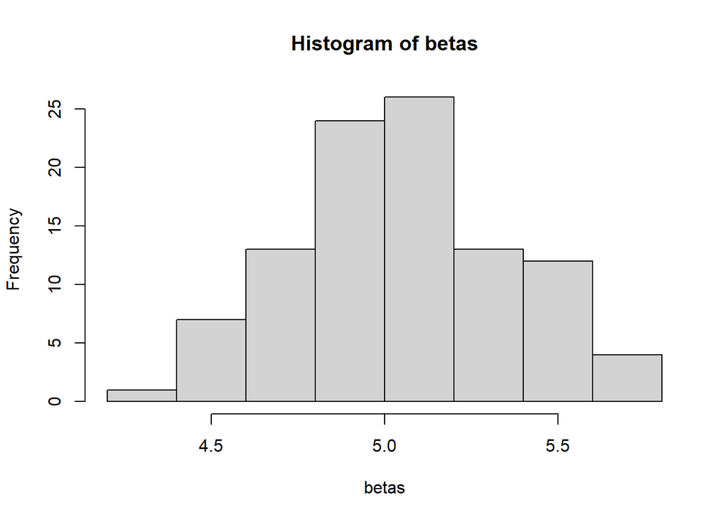

```r
nRep <- 100 # number of replicates
betas <- rep(0, nRep)
var_res <- rep(0, nRep)

for (i in seq(1,nRep, by = 1))
{

  set.seed(i)
x <- runif(100) #Simulated predictor
y <- 2 + 5* x  + rnorm(100) # generated response, with true sigma^2 = 1

modSim <- lm(y ~ x) #Regression model

betas[i] <- coef(modSim)[2]
var_res[i] <- (summary(modSim)$sigma)^2

}

# Histogram
 hist(betas)
```

```r
mean(betas)
```

```
## [1] 5.05647
```

```r
mean(var_res)
```

```
## [1] 0.987737
```

## Exercise 6.

Consider the data set `mtcars` available in R. It gives a comparison between different car models in terms of mileage per gallon (`mpg`), cylinder displacement(`disp`), horse power(`hp`), weight of the car(`wt`).

The goal of our model is to create the relationship between `mpg` as a response variable with `disp`,`hp` and `wt` as predictor variables.

1. Obtain the LS estimates of the coefficients using both `lm()` function and give the estimated model.

```r
cars_data <- mtcars[,c("mpg","disp","hp","wt")]
head(cars_data)
```

```
##                    mpg disp  hp    wt
## Mazda RX4         21.0  160 110 2.620
## Mazda RX4 Wag     21.0  160 110 2.875
## Datsun 710        22.8  108  93 2.320
## Hornet 4 Drive    21.4  258 110 3.215
## Hornet Sportabout 18.7  360 175 3.440
## Valiant           18.1  225 105 3.460
```

```r
model_cars <- lm(mpg~disp+hp+wt, data = cars_data)

# Show the model.
summary(model_cars)
```

```
##
## Call:
## lm(formula = mpg ~ disp + hp + wt, data = cars_data)
##
## Residuals:
##    Min     1Q Median     3Q    Max
## -3.891 -1.640 -0.172  1.061  5.861
##
## Coefficients:
##              Estimate Std. Error t value Pr(>|t|)
## (Intercept) 37.105505   2.110815  17.579  < 2e-16 ***
## disp        -0.000937   0.010350  -0.091  0.92851
## hp          -0.031157   0.011436  -2.724  0.01097 *
## wt          -3.800891   1.066191  -3.565  0.00133 **
## ---
## Signif. codes:  0 '***' 0.001 '**' 0.01 '*' 0.05 '.' 0.1 ' ' 1
##
## Residual standard error: 2.639 on 28 degrees of freedom
## Multiple R-squared:  0.8268, Adjusted R-squared:  0.8083
## F-statistic: 44.57 on 3 and 28 DF,  p-value: 8.65e-11
```

```r
coef(model_cars)
```

```
##   (Intercept)          disp            hp            wt
## 37.1055052690 -0.0009370091 -0.0311565508 -3.8008905826
```

2. We could also create the design matrix as the code below. Check the column corresponding to the intercept.

```r
(X <- model.matrix(model_cars))
```

```
##                     (Intercept)  disp  hp    wt
## Mazda RX4                     1 160.0 110 2.620
## Mazda RX4 Wag                 1 160.0 110 2.875
## Datsun 710                    1 108.0  93 2.320
## Hornet 4 Drive                1 258.0 110 3.215
## Hornet Sportabout             1 360.0 175 3.440
## Valiant                       1 225.0 105 3.460
## Duster 360                    1 360.0 245 3.570
## Merc 240D                     1 146.7  62 3.190
## Merc 230                      1 140.8  95 3.150
## Merc 280                      1 167.6 123 3.440
## Merc 280C                     1 167.6 123 3.440
## Merc 450SE                    1 275.8 180 4.070
## Merc 450SL                    1 275.8 180 3.730
## Merc 450SLC                   1 275.8 180 3.780
## Cadillac Fleetwood            1 472.0 205 5.250
## Lincoln Continental           1 460.0 215 5.424
## Chrysler Imperial             1 440.0 230 5.345
## Fiat 128                      1  78.7  66 2.200
## Honda Civic                   1  75.7  52 1.615
## Toyota Corolla                1  71.1  65 1.835
## Toyota Corona                 1 120.1  97 2.465
## Dodge Challenger              1 318.0 150 3.520
## AMC Javelin                   1 304.0 150 3.435
## Camaro Z28                    1 350.0 245 3.840
## Pontiac Firebird              1 400.0 175 3.845
## Fiat X1-9                     1  79.0  66 1.935
## Porsche 914-2                 1 120.3  91 2.140
## Lotus Europa                  1  95.1 113 1.513
## Ford Pantera L                1 351.0 264 3.170
## Ferrari Dino                  1 145.0 175 2.770
## Maserati Bora                 1 301.0 335 3.570
## Volvo 142E                    1 121.0 109 2.780
## attr(,"assign")
## [1] 0 1 2 3
```

```r
y <- as.vector(cars_data$mpg)

beta <- solve(t(X)%*%X)%*%(t(X)%*%y)
```

3. Calculate the estimated error variance and the estimated covariance matrix of the coefficients:

```r
 e <- y - X %*% beta
 ete <- t(e) %*% e
 n <- nrow(X)
 k <- 2
 (S2e <- as.numeric(ete/(n-(k+1))))
```

[output not shown]

```r
 (Vb <- S2e * solve(t(X)%*% X) )
```

[output not shown]

## Exercise 7 (optional)

Gauss-Markov theorem implies that least-squares estimator $\textbf{b} = \textbf{M}\textbf{y}$ (with $\textbf{M}= (\textbf{X}'\textbf{X})^{-1}\textbf{X}'$) is the most efficient (i.e., has the smallest sampling variance). Prove it.

*Hint: Assume that there is another linear estimator $\tilde{\textbf{b}} = \tilde{M}\textbf{y}$ which is also unbiased but has a smaller variance than $\textbf{b}$. Choose $\tilde{M} = A + \textbf{M}$ and show that $A = \textbf{0}$, i.e, both $\textbf{b}$ and $\tilde{\textbf{b}}$ are identical. Check the variance of this hypothetical estimator*.

**Answer**

Since $\tilde{\textbf{b}}$ is unbiased, then we have

$\beta = E(\tilde{\textbf{b}}) = E((A + \textbf{M})\textbf{y}) = E(A\textbf{y}) + E(\textbf{M}\textbf{y}) = \\$ $= \beta + A E(\textbf{y}) = \beta + A \textbf{X}\beta$.

Therefore $A \textbf{X}\beta = 0$, for any $\beta$. This means $A \textbf{X} = \textbf{0}$.

Now let’s look at the variance of $\tilde{\textbf{b}}$.

$V(\tilde{\textbf{b}}) = (\textbf{M} + A) V(\textbf{y}) ( \textbf{M} + A)' =(\textbf{M} + A) \sigma^2 I ( \textbf{M} + A)' =\\$

$=\sigma^2 (\textbf{M}\textbf{M}' + \textbf{M}A' + A \textbf{M}' + AA') =\sigma^2 (\textbf{M}\textbf{M}' + AA')$.

The last equation is due to $A \textbf{M}' = A \textbf{X} (\textbf{X}'\textbf{X})^{-1} = 0$. The same way, $A \textbf{M}' = (A \textbf{M}')' = 0$. Therefore, we have

$V(\tilde{\textbf{b}}) = \sigma^2 (\textbf{M}\textbf{M}' + AA')$. As assumed above, the estimator $\tilde{\textbf{b}}$ has smaller variance than ${\textbf{b}}$ (which is $V({\textbf{b}}) = \sigma^2 (\textbf{M}\textbf{M}')$, check it). On the other hand

$V(\tilde{\textbf{b}}_j) = \sigma^2 (\sum_i^n m_{ji}^2 + \sum_i^n a_{ji}^2)$, for every $\tilde{\textbf{b}}_j$. Here, the sum $\sum_i^n a_{ji}^2$ is positive, which means the smallest variance is achieved when $A = \textbf{0}$. This means

$\tilde{\textbf{b}} = \tilde{M}\textbf{y} = ( A + \textbf{M} ) \textbf{y} = (A + \textbf{0})\textbf{y} = \textbf{b}$.

## Exercise 8 (optional)

Recall the linear models $\textbf{y} = \textbf{X}\beta + \epsilon$, with $\epsilon \sim N(\textbf{0}, \sigma^2 I)$ for $\beta_{1\times k}$ (k predictors). Provide the logarithm of the likelihood (i.e., log-likelihood) function and obtain MLE for $\beta$ and $\sigma^2$ by maximizing the log-likelihood function.

**Answer**

From the normality assumption, it follows that

$L(\beta, \sigma^2) = (2\pi \sigma^2)^{-n/2} \exp \left[ - \sum_{i=1}^n(\epsilon_i)^2 / (2\sigma ^2 )\right] = (2\pi \sigma^2)^{-n/2} \exp \left[ - \sum_{i=1}^n(\textbf{y}_i - \textbf{X}_i\beta )^2 / (2\sigma ^2 )\right] =\\$

$(2\pi \sigma^2)^{-n/2} \exp \left[ - (\textbf{y} - \textbf{X}\beta )'(\textbf{y} - \textbf{X}\beta ) / (2\sigma ^2 )\right]\\$

$log L(\mu, \sigma^2) = - n log_e (2\pi) /2 - log (\sigma^2) n/2 - (\textbf{y} - \textbf{X}\beta )'(\textbf{y} - \textbf{X}\beta ) / (2 \sigma^2)$

Setting the partial derivatives to zero, we obtain

$\partial log_e L / \partial \beta = \textbf{X}' (\textbf{y} - \textbf{X}\beta )/ ( \sigma^2) = 0$

$\partial log_e L / \partial (\sigma^2) = - n/\sigma^2 + (\textbf{y} - \textbf{X}\beta )'(\textbf{y} - \textbf{X}\beta ) / ( 2 \sigma^4) = 0$

The first equation gives the same estimator as the LS estimator for $\beta$, i.e., $\hat{\beta} = (\textbf{X}'\textbf{X})^{-1}(\textbf{X}'\textbf{Y})$.

The second equation gives the MLE for $\sigma^2$, i.e., $\hat{\sigma}^2 = (\textbf{y} - \textbf{X}\hat{\beta} )'(\textbf{y} - \textbf{X}\hat{\beta})/n = \textbf{e}'\textbf{e}/n$.

Note that the MLE estimator is not unbiased.